# Practical_ML_project

Maiia Vasileva

2024-07-16

# Background

Using devices such as Jawbone Up, Nike FuelBand, and Fitbit it is now possible to collect a large amount of data about personal activity relatively inexpensively. These type of devices are part of the quantified self movement – a group of enthusiasts who take measurements about themselves regularly to improve their health, to find patterns in their behavior, or because they are tech geeks. One thing that people regularly do is quantify how much of a particular activity they do, but they rarely quantify how well they do it. In this project, your goal will be to use data from accelerometers on the belt, forearm, arm, and dumbell of 6 participants.

# Overview

In this project, our goal is to predict the manner in which the samplers did the exercise. Used data from accelerometers on the belt, forearm, arm, and dumbell of 6 participants. They were asked to perform barbell lifts correctly and incorrectly in 5 different ways.

Download Training and Testing Datasets

```r
set.seed(555)
url_training <- "https://d396qusza40orc.cloudfront.net/predmachlearn/pml-training.csv"
download.file(url_training, destfile = "pml-training.csv")

url_testing <- "https://d396qusza40orc.cloudfront.net/predmachlearn/pml-testing.csv"
download.file(url_testing, destfile = "pml-testing.csv")
```

Read Data sets

```r
Training <- read.csv(url_training, na.strings=c("NA",""), header=TRUE)
dim(Training)
```

```
## [1] 19622   160
```

```r
Testing <- read.csv(url_testing, na.strings=c("NA",""), header=TRUE)
dim(Testing)
```

```
## [1]  20 160
```

Data Cleaning Delete Predictors from the Training Dataset which contain missing values

```r
Training <- Training[, colSums(is.na(Training)) == 0]
Testing <- Testing[, colSums(is.na(Testing)) == 0]

# Remove columns which are unfit for prediction

Train <- Training[, -(1:7)]
Test <- Testing[, -(1:7)]

# Remaining Column Names
colnames(Train)
```

```
##  [1] "roll_belt"            "pitch_belt"           "yaw_belt"
##  [4] "total_accel_belt"     "gyros_belt_x"         "gyros_belt_y"
##  [7] "gyros_belt_z"         "accel_belt_x"         "accel_belt_y"
## [10] "accel_belt_z"         "magnet_belt_x"        "magnet_belt_y"
## [13] "magnet_belt_z"        "roll_arm"             "pitch_arm"
## [16] "yaw_arm"              "total_accel_arm"      "gyros_arm_x"
## [19] "gyros_arm_y"          "gyros_arm_z"          "accel_arm_x"
## [22] "accel_arm_y"          "accel_arm_z"          "magnet_arm_x"
## [25] "magnet_arm_y"         "magnet_arm_z"         "roll_dumbbell"
## [28] "pitch_dumbbell"       "yaw_dumbbell"         "total_accel_dumbbell"
## [31] "gyros_dumbbell_x"     "gyros_dumbbell_y"     "gyros_dumbbell_z"
## [34] "accel_dumbbell_x"     "accel_dumbbell_y"     "accel_dumbbell_z"
## [37] "magnet_dumbbell_x"    "magnet_dumbbell_y"    "magnet_dumbbell_z"
## [40] "roll_forearm"         "pitch_forearm"        "yaw_forearm"
## [43] "total_accel_forearm"  "gyros_forearm_x"      "gyros_forearm_y"
## [46] "gyros_forearm_z"      "accel_forearm_x"      "accel_forearm_y"
## [49] "accel_forearm_z"      "magnet_forearm_x"     "magnet_forearm_y"
## [52] "magnet_forearm_z"     "classe"
```

```r
colnames(Test)
```

```
##  [1] "roll_belt"            "pitch_belt"           "yaw_belt"
##  [4] "total_accel_belt"     "gyros_belt_x"         "gyros_belt_y"
##  [7] "gyros_belt_z"         "accel_belt_x"         "accel_belt_y"
## [10] "accel_belt_z"         "magnet_belt_x"        "magnet_belt_y"
## [13] "magnet_belt_z"        "roll_arm"             "pitch_arm"
## [16] "yaw_arm"              "total_accel_arm"      "gyros_arm_x"
## [19] "gyros_arm_y"          "gyros_arm_z"          "accel_arm_x"
## [22] "accel_arm_y"          "accel_arm_z"          "magnet_arm_x"
## [25] "magnet_arm_y"         "magnet_arm_z"         "roll_dumbbell"
## [28] "pitch_dumbbell"       "yaw_dumbbell"         "total_accel_dumbbell"
## [31] "gyros_dumbbell_x"     "gyros_dumbbell_y"     "gyros_dumbbell_z"
## [34] "accel_dumbbell_x"     "accel_dumbbell_y"     "accel_dumbbell_z"
## [37] "magnet_dumbbell_x"    "magnet_dumbbell_y"    "magnet_dumbbell_z"
## [40] "roll_forearm"         "pitch_forearm"        "yaw_forearm"
## [43] "total_accel_forearm"  "gyros_forearm_x"      "gyros_forearm_y"
## [46] "gyros_forearm_z"      "accel_forearm_x"      "accel_forearm_y"
## [49] "accel_forearm_z"      "magnet_forearm_x"     "magnet_forearm_y"
## [52] "magnet_forearm_z"     "problem_id"
```

Partitioning the Training Dataset

```r
inTraining <- createDataPartition(Train$classe, p=0.7, list=FALSE)
Training_1 <- Train[inTraining, ]
Training_2 <- Train[-inTraining, ]
dim(Training_1); dim(Training_2)
```

```
## [1] 13737    53
```

```
## [1] 5885   53
```

Prediction with Decision Tree Modeling

```r
DT_Model <- rpart(classe ~ ., data=Training_1, method="class")
print(DT_Model, digits=3)
```

```
## n= 13737
##
## node), split, n, loss, yval, (yprob)
##       * denotes terminal node
##
##    1) root 13737 9830 A (0.28 0.19 0.17 0.16 0.18)
##      2) roll_belt< 130 12604 8710 A (0.31 0.21 0.19 0.18 0.11)
##        4) pitch_forearm< -34 1110    5 A (1 0.0045 0 0 0) *
##        5) pitch_forearm>=-34 11494 8700 A (0.24 0.23 0.21 0.2 0.12)
##         10) magnet_dumbbell_y< 436 9685 6960 A (0.28 0.18 0.24 0.19 0.11)
##           20) roll_forearm< 122 5979 3550 A (0.41 0.18 0.19 0.17 0.062)
##             40) magnet_dumbbell_z< -24.5 2085  675 A (0.68 0.21 0.017 0.073 0.028)
##               80) roll_forearm>=-136 1730  363 A (0.79 0.16 0.019 0.021 0.0052) *
##               81) roll_forearm< -136 355  211 B (0.12 0.41 0.0085 0.33 0.14) *
##             41) magnet_dumbbell_z>=-24.5 3894 2810 C (0.26 0.16 0.28 0.21 0.081)
##               82) accel_dumbbell_y>=-40.5 3422 2400 A (0.3 0.18 0.2 0.24 0.086)
##                164) yaw_belt>=170 436   52 A (0.88 0.055 0 0.062 0.0023) *
##                165) yaw_belt< 170 2986 2190 D (0.21 0.2 0.22 0.27 0.098)
##                  330) pitch_belt< -43.2 322   53 B (0.019 0.84 0.075 0.04 0.031) *
##                  331) pitch_belt>=-43.2 2664 1880 D (0.24 0.12 0.24 0.29 0.11)
##                    662) roll_belt>=126 638  255 C (0.35 0.034 0.6 0.013 0.0047)
##                     1324) magnet_dumbbell_z< 23.5 215   18 A (0.92 0 0.084 0 0) *
##                     1325) magnet_dumbbell_z>=23.5 423   58 C (0.059 0.052 0.86 0.019 0.0071) *
##                    663) roll_belt< 126 2026 1260 D (0.2 0.15 0.13 0.38 0.14)
##                     1326) accel_dumbbell_z< 27.5 1479  829 D (0.26 0.089 0.18 0.44 0.034)
##                       2652) accel_forearm_x>=-79.5 793  445 A (0.44 0.11 0.16 0.23 0.054) *
##                       2653) accel_forearm_x< -79.5 686  221 D (0.057 0.061 0.19 0.68 0.012) *
##                     1327) accel_dumbbell_z>=27.5 547  317 E (0.033 0.32 0.0073 0.22 0.42)
##                       2654) roll_dumbbell< 36.7 157   33 B (0.038 0.79 0.025 0.076 0.07) *
##                       2655) roll_dumbbell>=36.7 390  171 E (0.031 0.13 0 0.28 0.56) *
##               83) accel_dumbbell_y< -40.5 472   61 C (0.011 0.044 0.87 0.034 0.04) *
##           21) roll_forearm>=122 3706 2490 C (0.079 0.18 0.33 0.23 0.18)
##             42) magnet_dumbbell_y< 290 2160 1120 C (0.094 0.13 0.48 0.15 0.14)
##               84) magnet_forearm_z< -251 170   33 A (0.81 0.053 0 0.059 0.082) *
##               85) magnet_forearm_z>=-251 1990  950 C (0.033 0.14 0.52 0.16 0.14)
##                170) pitch_belt>=26.1 145   30 B (0.1 0.79 0.021 0 0.083) *
##                171) pitch_belt< 26.1 1845  808 C (0.027 0.089 0.56 0.17 0.15) *
##             43) magnet_dumbbell_y>=290 1546 1020 D (0.058 0.25 0.11 0.34 0.24)
##               86) accel_forearm_x>=-90.5 966  639 E (0.052 0.32 0.16 0.13 0.34)
##                172) magnet_arm_y>=196 403  182 B (0.017 0.55 0.23 0.092 0.11) *
##                173) magnet_arm_y< 196 563  281 E (0.076 0.16 0.1 0.16 0.5) *
##               87) accel_forearm_x< -90.5 580  184 D (0.069 0.13 0.034 0.68 0.084) *
##         11) magnet_dumbbell_y>=436 1809  898 B (0.036 0.5 0.036 0.23 0.2)
##           22) total_accel_dumbbell>=5.5 1283  455 B (0.051 0.65 0.051 0.018 0.24)
##             44) roll_belt>=-0.605 1082  254 B (0.06 0.77 0.06 0.021 0.093) *
##             45) roll_belt< -0.605 201    0 E (0 0 0 0 1) *
##           23) total_accel_dumbbell< 5.5 526  139 D (0 0.16 0.0019 0.74 0.1) *
##      3) roll_belt>=130 1133   12 E (0.011 0 0 0 0.99) *
```

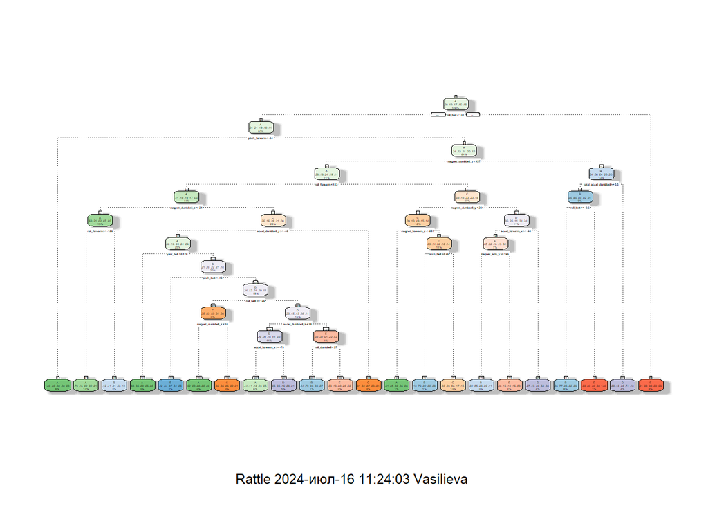

```r
fancyRpartPlot(DT_Model)
```

```r
A_prediction <- predict(DT_Model, Training_1, type = "class")
cmtree <- confusionMatrix(A_prediction, as.factor(Training_1$classe))
cmtree
```

```
## Confusion Matrix and Statistics
##
##           Reference
## Prediction    A    B    C    D    E
##          A 3538  411  179  259   67
##          B  142 1701  192  201  228
##          C   80  208 1813  344  295
##          D   79  200  153 1248  112
##          E   67  138   59  200 1823
##
## Overall Statistics
##
##                Accuracy : 0.7369
##                  95% CI : (0.7295, 0.7443)
##     No Information Rate : 0.2843
##     P-Value [Acc > NIR] : < 2.2e-16
##
##                   Kappa : 0.6654
##
##  Mcnemar's Test P-Value : < 2.2e-16
##
## Statistics by Class:
##
##                      Class: A Class: B Class: C Class: D Class: E
## Sensitivity            0.9058   0.6400   0.7567  0.55417   0.7220
## Specificity            0.9068   0.9311   0.9183  0.95263   0.9586
## Pos Pred Value         0.7943   0.6903   0.6617  0.69643   0.7971
## Neg Pred Value         0.9604   0.9151   0.9470  0.91595   0.9387
## Prevalence             0.2843   0.1935   0.1744  0.16394   0.1838
## Detection Rate         0.2576   0.1238   0.1320  0.09085   0.1327
## Detection Prevalence   0.3242   0.1794   0.1995  0.13045   0.1665
## Balanced Accuracy      0.9063   0.7855   0.8375  0.75340   0.8403
```

Random Forest Modeling

```r
set.seed(555)
RF_Model <- randomForest(as.factor(classe) ~ ., data=Training_1)
B_Prediction <- predict(RF_Model, Training_1, type = "class")
cmrf <- confusionMatrix(B_Prediction, as.factor(Training_1$classe))
cmrf
```

```
## Confusion Matrix and Statistics
##
##           Reference
## Prediction    A    B    C    D    E
##          A 3906    0    0    0    0
##          B    0 2658    0    0    0
##          C    0    0 2396    0    0
##          D    0    0    0 2252    0
##          E    0    0    0    0 2525
##
## Overall Statistics
##
##                Accuracy : 1
##                  95% CI : (0.9997, 1)
##     No Information Rate : 0.2843
##     P-Value [Acc > NIR] : < 2.2e-16
##
##                   Kappa : 1
##
##  Mcnemar's Test P-Value : NA
##
## Statistics by Class:
##
##                      Class: A Class: B Class: C Class: D Class: E
## Sensitivity            1.0000   1.0000   1.0000   1.0000   1.0000
## Specificity            1.0000   1.0000   1.0000   1.0000   1.0000
## Pos Pred Value         1.0000   1.0000   1.0000   1.0000   1.0000
## Neg Pred Value         1.0000   1.0000   1.0000   1.0000   1.0000
## Prevalence             0.2843   0.1935   0.1744   0.1639   0.1838
## Detection Rate         0.2843   0.1935   0.1744   0.1639   0.1838
## Detection Prevalence   0.2843   0.1935   0.1744   0.1639   0.1838
## Balanced Accuracy      1.0000   1.0000   1.0000   1.0000   1.0000
```

Results: We were able to obtain 100% of accuracy with Random Forest model compared with Decision Tree model accuracy 74%. Random Forest model will be chosen to predict the 20 test cases below.

Predicting Test Data

```r
B_Prediction <- predict(RF_Model, Test, type = "class")
B_Prediction
```

```
##  1  2  3  4  5  6  7  8  9 10 11 12 13 14 15 16 17 18 19 20
##  B  A  B  A  A  E  D  B  A  A  B  C  B  A  E  E  A  B  B  B
## Levels: A B C D E
```